# TikTok Influencer Analysis Report

Data Analysis Team

2025-10-31

## Intro: TikTok data collection and entity mapping

- TikTokUser (`TikTokUser` node; collection: `tiktok_user_info`)
  - Collected via user profile fetch in the ETL (see `dags/tiktok_dag.py` → MERGE `TikTokUser` with display_name, bio, avatar, counters)
  - Report CSVs used: `followers_count.csv`, `likes_count.csv`, `user_verification.csv`, `user_bios.csv`
- TikTokVideo (`TikTokVideo` node; collection: `tiktok_videos`)
  - Collected via channel/user video listing + detail enrich (see `dags/tiktok_video_dag.py` → MERGE `TikTokVideo` with counts, duration, labels, tags)
  - Report CSVs used: `user_video_duration.csv`, `user_videos_additional_analysis.csv`, `video_field_presence_stats.csv`, `user_videos_comprehensive_analysis.csv`
- TikTokComment (`TikTokComment` node; collection: `tiktok_video_comments`)
  - Collected via video comments fetch (see `dags/tiktok_video_comments_dag.py` → MERGE `TikTokComment` and link to `TikTokVideo`)
  - Report CSVs used: `video_comments_stats.csv` (to be refined)
- TikTokHashTag (`Hashtag` node)
  - Extracted from `TikTokVideo` hashtags and linked with `HAS_HASHTAG` (`dags/tiktok_video_dag.py`)
- TikTokSticker (`Sticker` node)
  - Extracted from `TikTokVideo` stickers and linked with `HAS_STICKER` (`dags/tiktok_video_dag.py`)

## Data Completeness

```
## ### Per-Property Completeness (%)
```

| Entity | Property | NonMissing | Total | CompletenessPct |
| --- | --- | --- | --- | --- |
| TikTokComment | create_time | 2406062 | 2406063 | 100 |
| TikTokComment | like_count | 2406062 | 2406063 | 100 |
| TikTokComment | reply_count | 2406062 | 2406063 | 100 |
| TikTokComment | username | 2406062 | 2406063 | 100 |
| TikTokComment | video_id | 2406061 | 2406063 | 100 |
| TikTokComment | text | 2404607 | 2406063 | 99.9 |
| TikTokComment | comment_id | 1 | 2406063 | 0 |
| TikTokHashTag | username | 52680 | 52680 | 100 |
| TikTokHashTag | video_id | 52680 | 52680 | 100 |
| TikTokHashTag | hashtag_name | 45609 | 52680 | 86.6 |

[output cut: 33 more lines]

## Executive Summary

This report provides a comprehensive analysis of TikTok influencer data, examining user engagement patterns, content characteristics, and platform dynamics. The analysis covers multiple dimensions including follower metrics, content performance, user verification status, and engagement rates.

### Data Overview

```
## **Total TikTok Users Analyzed**: 157
```

## 1. User Engagement Analysis

### Follower Distribution

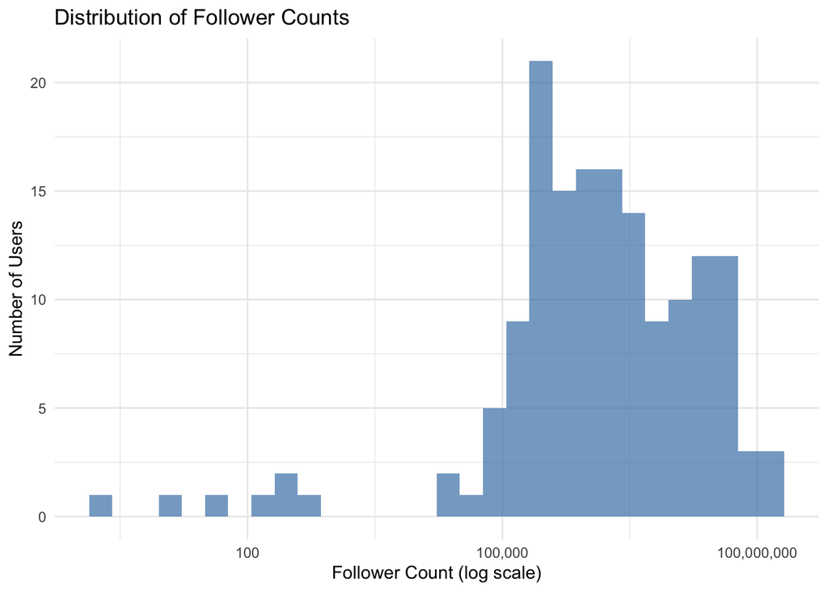

```
## **Follower Count Statistics:**
## - Mean: 11,454,394
## - Median: 1,377,669
## - Max: 162,375,800
## - Min: 0
```

### Likes Analysis

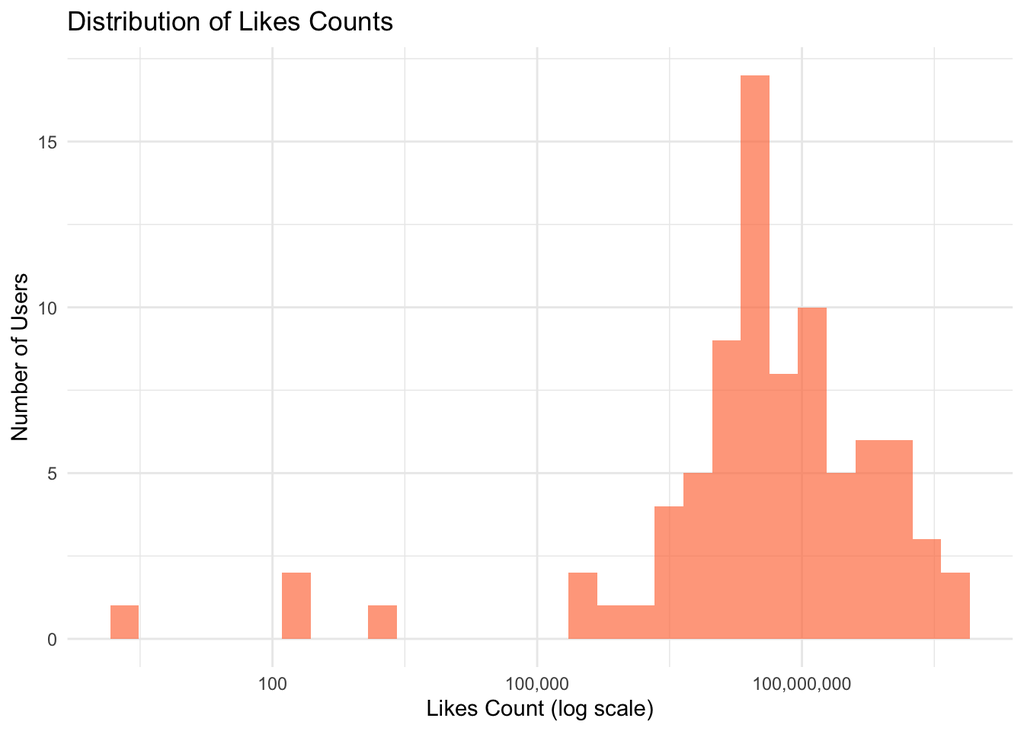

```
## **Likes Count Statistics:**
## - Mean: 426,539,748
## - Median: 41,076,462
## - Max: 7,819,632,818
## - Min: 0
```

## 2. User Verification Status

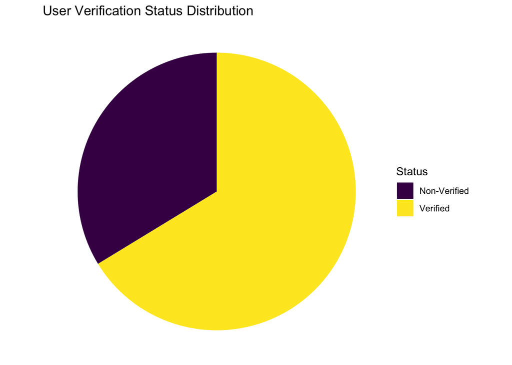

```
## **Verification Summary:**
## - Verified Users: 57 ( 66.3 %)
## - Non-Verified Users: 29 ( 33.7 %)
```

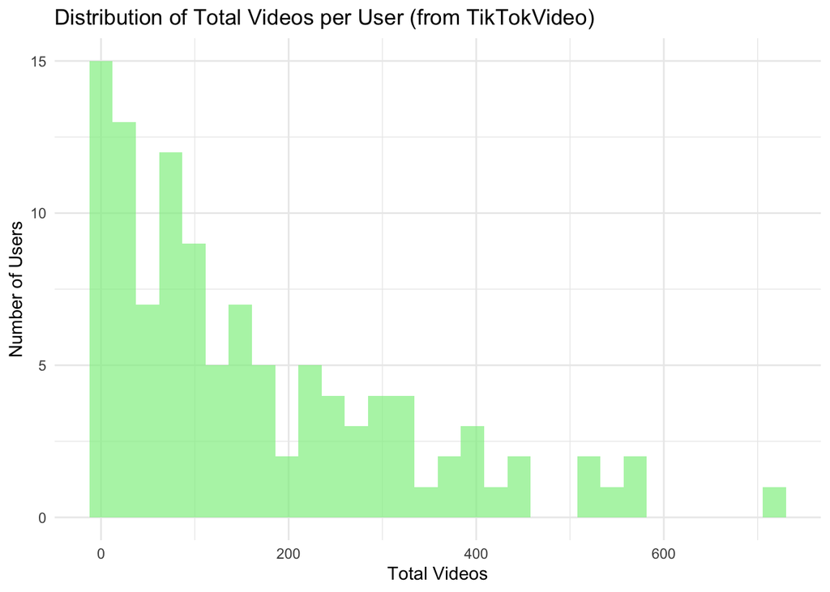

```
## **Video Statistics (from TikTokVideo):**
## - Mean Videos per User: 162.51
## - Median Videos per User: 102
## - Max Videos per User: 719
## - Min Videos per User: 1
```

## 4. User Video Statistics

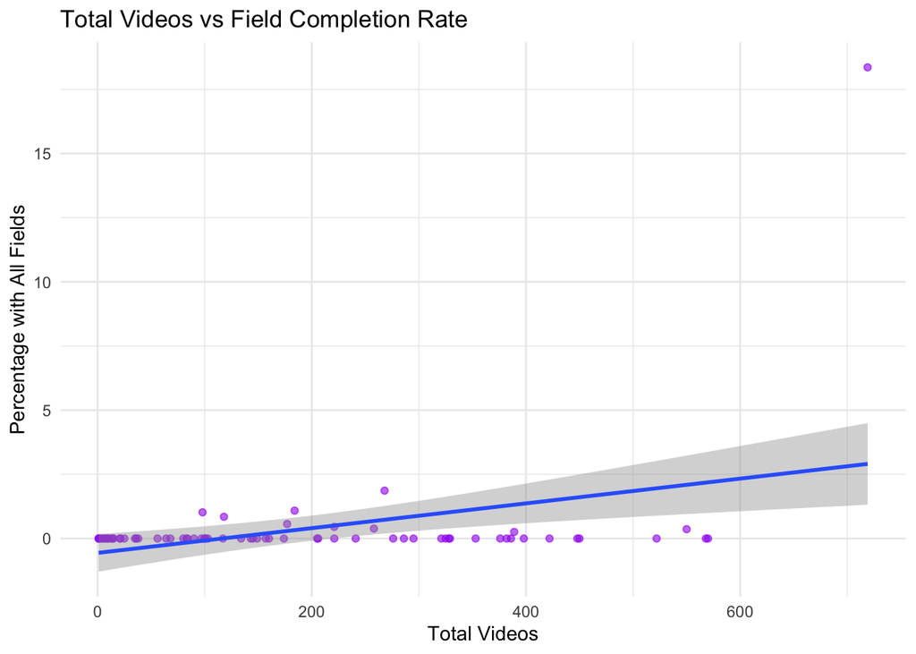

```
## **Video Statistics:**
## - Average Videos per User: 190.87
## - Average Field Completion Rate: 0.36 %
```

## 5. Popularity and Engagement Analysis

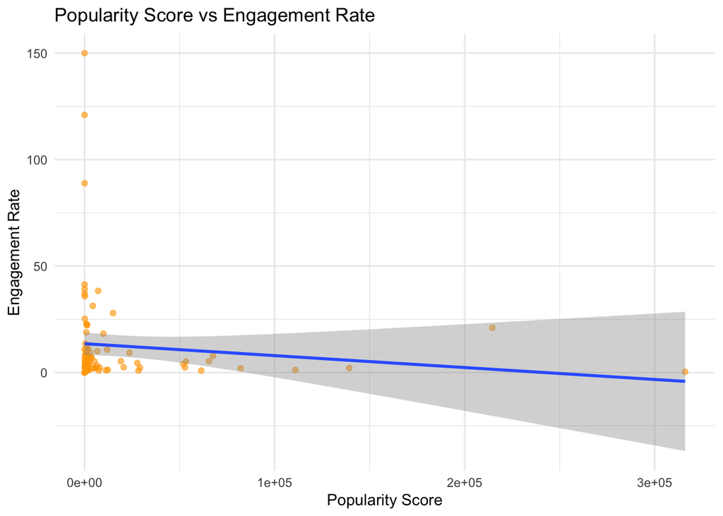

Top 10 Users by Engagement Rate

| username | engagement_rate | popularity_score |
| --- | --- | --- |
| iamcadib | 150.00 | 0.00 |
| tiktokkiedon | 120.98 | 21.39 |
| isaevanyoutube | 88.91 | 13.66 |
| goudmijn | 41.35 | 0.02 |
| chiieffff | 39.12 | 43.41 |
| icespicee | 38.36 | 7124.49 |
| fatoemakerss | 36.96 | 0.03 |
| gio | 35.82 | 159.52 |
| mattsturniolo | 31.32 | 4358.22 |
| ishowspeed | 27.93 | 14985.55 |

## 6. Field Presence Analysis

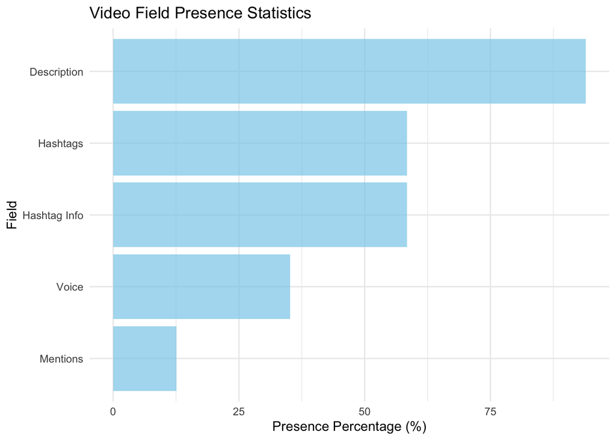

Field Presence Statistics

| Field | Percentage |
| --- | --- |
| Voice | 35.20695 |
| Description | 93.93010 |
| Hashtags | 58.44622 |
| Hashtag Info | 58.44622 |
| Mentions | 12.61882 |

## 7. Comments Analysis

```
## **Comments Statistics:**
## - Comments data available but requires data structure fix
## - This section will be updated once the CSV generation is corrected
```

## 8. User Bios Analysis

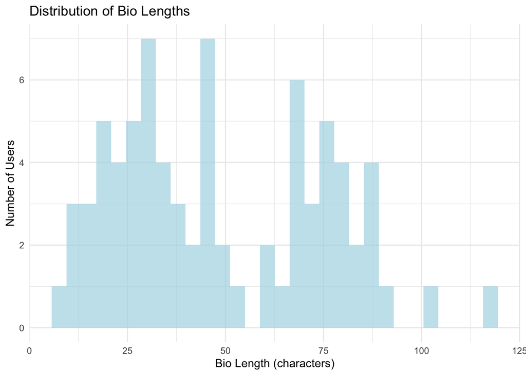

```
## **Bio Length Statistics:**
## - Mean Length: 48.78 characters
## - Median Length: 44 characters
## - Max Length: 116 characters
```

## 9. Comprehensive Analysis

[output not shown]

## 10. Hashtag Frequencies

Top 50 Hashtags by Occurrence (TikTok)

[output not shown]

## Sticker Frequencies

```
## Sticker frequency data not available
```

## Conclusion

This analysis provides insights into TikTok influencer behavior, engagement patterns, and content characteristics. The data reveals trends in follower distribution, verification status, video performance, and user engagement metrics that can inform content strategy and platform understanding.

*Report generated on 2025-10-31*